# Projekt1

## Third model

```r
# Train the Naive Bayes model
nb_model_3 <- naiveBayes(class ~ number_inpatient + number_emergency, data = train_data, laplace = best_alpha)
nb_model_3
```

```
##
## Naive Bayes Classifier for Discrete Predictors
##
## Call:
## naiveBayes.default(x = X, y = Y, laplace = laplace)
##
## A-priori probabilities:
## Y
##         0         1
## 0.5332984 0.4667016
##
## Conditional probabilities:
##    number_inpatient
## Y        [,1]      [,2]
##   0 0.1320074 0.2710997
##   1 0.2200543 0.3376476
##
##    number_emergency
## Y          [,1]        [,2]
##   0 0.001478484 0.006828055
##   1 0.003947409 0.015783463
```

```r
# Generate predictions using the Naive Bayes model
nb.prediction <- predict(nb_model_3, newdata = test_data)

# Create a confusion matrix
cm3 <- confusionMatrix(factor(nb.prediction), factor(test_data$class))
cm3
```

```
## Confusion Matrix and Statistics
##
##           Reference
## Prediction     0     1
##          0 13881 10411
##          1  1853  3270
##
##                Accuracy : 0.5831
##                  95% CI : (0.5774, 0.5887)
##     No Information Rate : 0.5349
##     P-Value [Acc > NIR] : < 2.2e-16
##
##                   Kappa : 0.1264
##
##  Mcnemar's Test P-Value : < 2.2e-16
##
##             Sensitivity : 0.8822
##             Specificity : 0.2390
##          Pos Pred Value : 0.5714
##          Neg Pred Value : 0.6383
##              Prevalence : 0.5349
##          Detection Rate : 0.4719
##    Detection Prevalence : 0.8258
##       Balanced Accuracy : 0.5606
##
##        'Positive' Class : 0
##
```

```r
nb_roc_3 <- prediction(as.numeric(nb.prediction), as.numeric(test_data$class))
nb_perf_3 <- performance(nb_roc_3, "tpr", "fpr")
nb_auc_3 <- performance(nb_roc_3, "auc")@y.values[[1]]
```

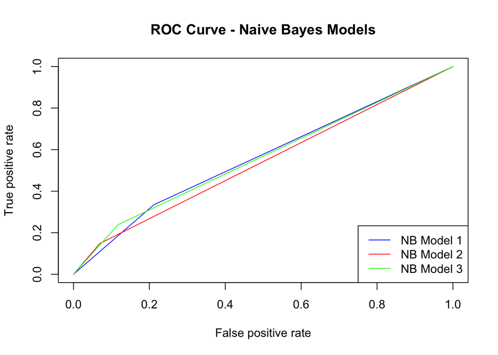

```r
# Plot ROC curves for Naive Bayes models
plot(nb_perf_1, col = "blue", main = "ROC Curve - Naive Bayes Models")
plot(nb_perf_2, col = "red", add = TRUE)
plot(nb_perf_3, col = "green", add = TRUE)

# Add legend
legend("bottomright", legend = c("NB Model 1", "NB Model 2", "NB Model 3"),
       col = c("blue", "red", "green"), lty = 1)
```

```r
# Print auROC for each Naive Bayes model
cat("auROC for Naive Bayes model 1:", nb_auc_1, "\n")
```

```
## auROC for Naive Bayes model 1: 0.5613857
```

```r
cat("auROC for Naive Bayes model 2:", nb_auc_2, "\n")
```

```
## auROC for Naive Bayes model 2: 0.5393455
```

```r
cat("auROC for Naive Bayes model 3:", nb_auc_3, "\n")
```

```
## auROC for Naive Bayes model 3: 0.5606236
```

Worst Model (Naive Bayes 2 - NB2): NB2 has the lowest AUC among the models. NB2’s lower precision with significantly high recall indicates high ammount of false positive predictions.

```r
# Function to extract metrics from confusion matrix
extract_metrics <- function(confusion_matrix) {
  accuracy <- confusion_matrix$overall["Accuracy"]
  precision <- confusion_matrix$byClass["Pos Pred Value"]
  recall <- confusion_matrix$byClass["Sensitivity"]
  return(c(accuracy = accuracy, precision = precision, recall = recall))
}

# Extract metrics for each confusion matrix
matrics0 <- extract_metrics(cm0)
metrics1 <- extract_metrics(cm1)
metrics2 <- extract_metrics(cm2)
metrics3 <- extract_metrics(cm3)

# Create a table without AUC values for now
metrics_table <- rbind(matrics0, metrics1, metrics2, metrics3)
rownames(metrics_table) <- c("LR time_in_hospital + number_inpatient", "NB1 time_in_hospital + number_inpatient", "NB2 number_diagnoses + number_emergency", "NB3 number_inpatient + number_emergency")
colnames(metrics_table) <- c("Accuracy", "Precision", "Recall")

# Insert the AUC values as the first column in the table
AUC_values <- c("", nb_auc_1, nb_auc_2, nb_auc_3)
metrics_table <- cbind(AUC = AUC_values, metrics_table)

# Print the table
metrics_table
```

```
##                                         AUC                 Accuracy
## LR time_in_hospital + number_inpatient  ""                  "0.577222505524392"
## NB1 time_in_hospital + number_inpatient "0.561385671371003" "0.577222505524392"
## NB2 number_diagnoses + number_emergency "0.539345541582615" "0.566683664796872"
## NB3 number_inpatient + number_emergency "0.56062359110758"  "0.583069862315145"
##                                         Precision           Recall
## LR time_in_hospital + number_inpatient  "0.576669146364143" "0.788292868946231"
## NB1 time_in_hospital + number_inpatient "0.576669146364143" "0.788292868946231"
## NB2 number_diagnoses + number_emergency "0.556784492588369" "0.931041057582306"
## NB3 number_inpatient + number_emergency "0.571422690597728" "0.88222956654379"
```

# Regression

H0: There is no association between the number of emergency admissions (number_emergency) and the number of diagnoses (number_diagnoses), suggesting that the frequency of emergency admissions does not have a linear relationship with the number of diagnoses.

H0: There is no association between the race of the patient (race) and the number of diagnoses (number_diagnoses), indicating that the patient’s race does not have a linear relationship with the number of diagnoses.

```r
train_index <- createDataPartition(df$number_diagnoses, p = 0.7, list = FALSE)
train_data_lm <- df[train_index, ]
test_data_lm <- df[-train_index, ]
```

```r
model <- lm(number_diagnoses ~ number_emergency + race, data=train_data_lm)
summary(model)
```

```
##
## Call:
## lm(formula = number_diagnoses ~ number_emergency + race, data = train_data_lm)
##
## Residuals:
##      Min       1Q   Median       3Q      Max
## -0.67849 -0.15361  0.07561  0.14639  0.56549
##
## Coefficients:
##                   Estimate Std. Error t value Pr(>|t|)
## (Intercept)      0.4097867  0.0022640  181.00   <2e-16 ***
## number_emergency 0.7688370  0.0549329   14.00   <2e-16 ***
## race             0.0146073  0.0008066   18.11   <2e-16 ***
## ---
## Signif. codes:  0 '***' 0.001 '**' 0.01 '*' 0.05 '.' 0.1 ' ' 1
##
## Residual standard error: 0.1816 on 68636 degrees of freedom
## Multiple R-squared:  0.00741,    Adjusted R-squared:  0.007381
## F-statistic: 256.2 on 2 and 68636 DF,  p-value: < 2.2e-16
```

```r
residuals <- residuals(model)
RSS <- sum(residuals^2)
RMSE <- sqrt(mean(residuals^2))
RSS; RMSE
```

```
## [1] 2264.198
```

```
## [1] 0.1816234
```

```r
regression_predictions <- predict(model, newdata = test_data_lm)
mse <- mean((regression_predictions - test_data$number_diagnoses)^2)
mse
```

```
## [1] 0.03335144
```

# Improving our model

1. Feature Engineering:
   - Feature Selection: Explore different feature selection techniques (e.g., recursive feature elimination, LASSO regularization) to identify the most relevant features for predicting readmission risk. Selecting only the most informative features can improve model performance.
   - Feature Engineering: Create new features based on domain knowledge or transformations of existing features to capture additional information that may be relevant for predicting readmission risk.
2. Model Selection and Tuning:
   - Model Selection: Experiment with different classification algorithms (e.g., random forests, gradient boosting machines, support vector machines) to identify the model that best captures the underlying patterns in the data.
   - Hyperparameter Tuning: Use techniques like grid search or random search to tune the hyperparameters of your selected model(s) for optimal performance. Tuning parameters such as regularization strength, tree depth, and learning rate can help improve model accuracy and generalization.